# LIGOtutorial814

This tutorial is developed based on the material on [Gravitational Wave Open Science Center](https://www.gw-openscience.org/) and the tutorial from Professor Philip Harris.

## Preparation

### Download the data

```
wget -P data https://www.gw-openscience.org/eventapi/html/GWTC-1-confident/GW150914/v3/H-H1_GWOSC_16KHZ_R1-1126257415-4096.hdf5
```

### Load libraries

```python
#----------------------------------------------------------------
# Load libraries
#----------------------------------------------------------------
import numpy as np
import math
from gwpy.timeseries import TimeSeries

import matplotlib.pyplot as plt
import matplotlib.mlab as mlab
import h5py

import os

%matplotlib inline
```

### Set input file and parameters

```python
#----------------------------------------------------------------
# Set parameters
#----------------------------------------------------------------
fn = 'data/H-H1_GWOSC_4KHZ_R1-1126257415-4096.hdf5' # data file
tevent = 1126259462.422 # Mon Sep 14 09:50:45 GMT 2015
evtname = 'GW150914' # event name

detector = 'H1' # detecotr: L1 or H1
```

### Load data

```python
#----------------------------------------------------------------
# Load LIGO data
#----------------------------------------------------------------
strain = TimeSeries.read(fn, format='hdf5.losc')
center = int(tevent)
strain = strain.crop(center-16, center+16)
```

## Analysis on a known event

### First look at data: raw time-series data

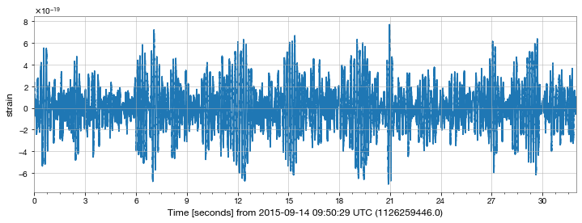

```python
#----------------------------------------------------------------
# Show LIGO strain vs. time
#----------------------------------------------------------------
plt.figure()
strain.plot()
plt.ylabel('strain')
plt.show()
```

The data are dominated by low frequency noise, and there is no way to see a signal here.

### Data in the Fourier domain: ASDs

Plotting these data in the Fourier domain gives us an idea of the frequency content of the data. A way to visualize the frequency content of the data is to plot the amplitude spectral density, ASD. The ASDs are the square root of the power spectral densities (PSDs), which are averages of the square of the fast fourier transforms (FFTs) of the data. They are an estimate of the "strain-equivalent noise" of the detectors versus frequency, which limit the ability of the detectors to identify GW signals.

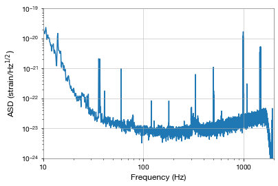

```python
#----------------------------------------------------------------
# Obtain the power spectrum density PSD / ASD
#----------------------------------------------------------------

asd = strain.asd(fftlength=8)

plt.clf()
asd.plot()
plt.xlim(10, 2000)
plt.ylim(1e-24, 1e-19)
plt.ylabel('ASD (strain/Hz$^{1/2})$')
plt.xlabel('Frequency (Hz)')
plt.show()
```

You can see strong spectral lines in the data. They are all of instrumental origin. Some are engineered into the detectors (mirror suspension resonances at ~500 Hz and harmonics, calibration lines, control dither lines, etc) and some (60 Hz and harmonics) are unwanted. We'll return to these, later.

You can't see the signal in this plot, since it is relatively weak and less than a second long, while this plot averages over 32 seconds of data. So this plot is entirely dominated by instrumental noise.

### Whitening data

From the ASD above, we can see that noise fluctuations are much larger at low and high frequencies and near spectral lines. We can "whiten" the data, suppressing the extra noise at low frequencies and at the spectral lines, to better see the weak signals in the most sensitive band.

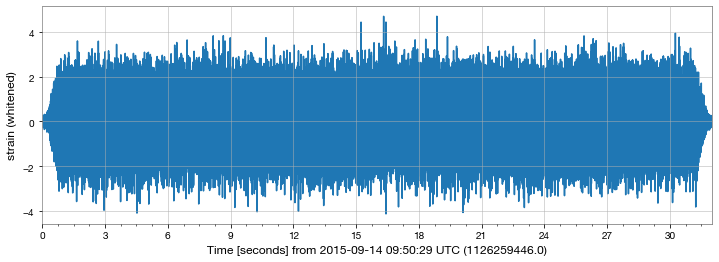

```python
#----------------------------------------------------------------
# Whitening data
#----------------------------------------------------------------

white_data = strain.whiten()

plt.clf()
white_data.plot()
plt.ylabel('strain (whitened)')
plt.show()
```

### Bandpassing filter

To get rid of remaining high frequency noise, we will also bandpass the data. The macro below shows you a framework to do bandpanssing, but you need to find proper frequency windows by yourself.

```python
bandpass_low = 30
bandpass_high = 400
print('# Here set:\nbandpass_low =\nbandpass_high =\n')
```

```
# Here set:
bandpass_low =
bandpass_high =
```

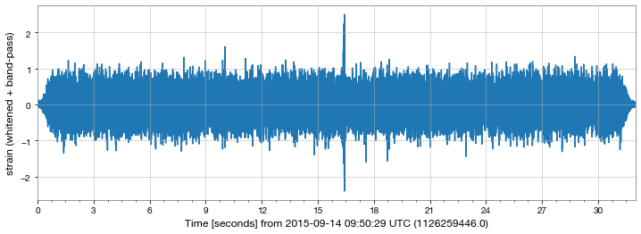

```python
#----------------------------------------------------------------
# Bandpass filtering
#----------------------------------------------------------------

white_data_bp = white_data.bandpass(bandpass_low, bandpass_high)

plt.clf()
white_data_bp.plot()
plt.ylabel('strain (whitened + band-pass)')
plt.show()
```

### Plot a q-transform of the data

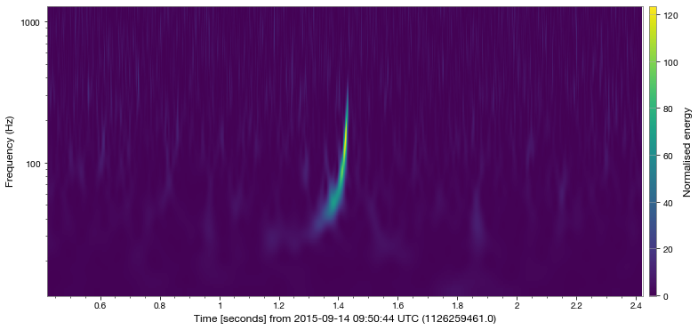

```python
#----------------------------------------------------------------
# q-transform
#----------------------------------------------------------------

dt = 1  #-- Set width of q-transform plot, in seconds
hq = strain.q_transform(outseg=(tevent-dt, tevent+dt))

plt.clf()
fig = hq.plot()
ax = fig.gca()
fig.colorbar(label="Normalised energy")
ax.grid(False)
ax.set_yscale('log')
plt.ylabel('Frequency (Hz)')
plt.show()
```

### Analytic model (under construction)

Combining knowledge of a little bit of GR and 8.01 physics, we can get the radiation power from this system \begin{eqnarray} \frac{dE_{tot}}{dt} & = & -\frac{2}{3}\left(\frac{G^2 M^5_{c}}{32\omega}\right)^{\frac{1}{3}}\dot{\omega}\\ \end{eqnarray} and the oscilliation frequency as a function of time $t$ \begin{eqnarray} \omega(t) & = & 2\pi\left(134\rm{Hz}\right)\left(\frac{1.21 M_{\odot}}{M_{c}}\right)^{\frac{5}{8}}\left(\frac{1\rm{s}}{\Delta t}\right)^{\frac{3}{8}} \end{eqnarray} Let's take a look at how it looks like.

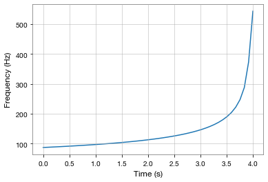

```python
#----------------------------------------------------------------
# Frequency analytic
#----------------------------------------------------------------

def gwfreq(iM,iT,iT0):
    const = (134.*np.pi*2)*np.power((1.21/iM),5./8.)
    output = const*np.power(np.maximum((iT0-iT),3e-2),-3./8.) # we can max it out above 500 Hz-ish
    return output

times = np.linspace(0., 4., 50)
freq = gwfreq(20, times, 4)

plt.clf()
plt.plot(times, freq)
plt.xlabel('Time (s)')
plt.ylabel('Frequency (Hz)')
plt.show()
```

### Analytic model - Wave form

By comibining the radiation power and frequency obtained above, we can get a wave form function \begin{eqnarray} f(t) = A(t)\cos(\omega(t)t+\phi) \end{eqnarray} \begin{eqnarray} f(t) & = & C(M_{c}\omega)^{\frac{10}{3}}(t)\cos(\omega(t)t+\phi)\rm{, for~t~\leq t_{0}} \\ f(t) & = & C(M_{c}\omega)^{\frac{10}{3}}(t)\cos(\omega(t_{0})t+\phi)e^{-\frac{\omega}{2\pi}\left(t-t_{0}\right)}\rm{, for~t > t_{0}} \\ \omega(t) & = & 2\pi\left(134\rm{Hz}\right)\left(\frac{1.21 M_{\odot}}{M_{c}}\right)^{\frac{5}{8}}\left(\frac{1\rm{s}}{t_0-t}\right)^{\frac{3}{8}} \end{eqnarray} For the amplitude variation, we can use the power output. Try to come up with a proper $A(t)$ using radiation power output. I have one answer in my mind, which leads to the shape below.

```python
#----------------------------------------------------------------
# Wave form analytic
#----------------------------------------------------------------

print('Define the model function w(t) here.')
print('osc(t, Mc, t0, C, phi)')

def osc(x,Mc,t0,C,phi):
    freq = gwfreq(Mc,x,t0)
    val = C*(np.cos(freq*(t0-x)+phi))*1e-12
    val = val*np.power(Mc*freq,10./3.)*(1*(x<=t0)+np.exp((freq/(2*np.pi))*(t0-x))*(x>t0))
    return val
```

```
Define the model function w(t) here.
osc(t, Mc, t0, C, phi)
```

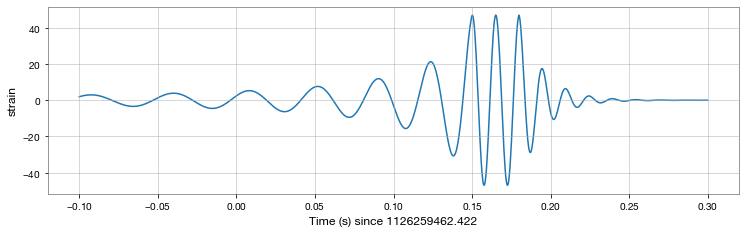

```python
# Draw the function defined
times = np.linspace(-0.1, 0.3, 1000)
freq = osc(times, 30, 0.18, 1, 0.0)
plt.figure(figsize=(12, 4))
plt.subplots_adjust(left=0.1, right=0.9, top=0.85, bottom=0.2)
plt.plot(times, freq)
plt.xlabel('Time (s) since '+str(tevent))
plt.ylabel('strain')
plt.show()
```

```python
# define osc_dif for lmfit::minimize()
def osc_dif(params, x, data, eps):
    iM=params["Mc"]
    iT0=params["t0"]
    norm=params["C"]
    phi=params["phi"]
    val=osc(x, iM, iT0, norm, phi)
    return (val-data)/eps
```

```
[[Fit Statistics]]
    # fitting method   = leastsq
    # function evals   = 81
    # data points      = 1228
    # variables        = 4
    chi-square         = 0.72586206
    reduced chi-square = 5.9302e-04
    Akaike info crit   = -9120.38392
    Bayesian info crit = -9099.93135
[[Variables]]
    Mc:   17.3561729 +/- 0.20106138 (1.16%) (init = 20)
    t0:   0.18039070 +/- 5.8553e-04 (0.32%) (init = 0.18)
    C:   -0.04145174 +/- 0.00201537 (4.86%) (init = 1)
    phi: -2.09189633 +/- 0.37798446 (18.07%) (init = 0)
[[Correlations]] (unreported correlations are < 0.100)
    C(t0, phi) = -0.981
    C(Mc, phi) =  0.893
    C(Mc, t0)  = -0.825
    C(Mc, C)   =  0.253
    C(C, phi)  =  0.209
    C(t0, C)   = -0.188
```

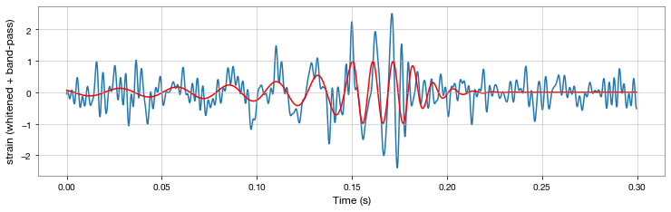

```python
#----------------------------------------------------------------
# Fit
#----------------------------------------------------------------

sample_times = white_data_bp.times.value
sample_data = white_data_bp.value
indxt = np.where((sample_times >= (tevent-0.17)) & (sample_times < (tevent+0.13)))
x = sample_times[indxt]
x = x-x[0]
white_data_bp_zoom = sample_data[indxt]

plt.figure(figsize=(12, 4))
plt.subplots_adjust(left=0.1, right=0.9, top=0.85, bottom=0.2)
plt.plot(x, white_data_bp_zoom)
plt.xlabel('Time (s)')
plt.ylabel('strain (whitened + band-pass)')
plt.savefig('strain_whiten_bandpass_nofit.png')

import lmfit
from lmfit import Model, minimize, fit_report, Parameters

model = lmfit.Model(osc)
p = model.make_params()
p['Mc'].set(20)     # Mass guess
p['t0'].set(0.18)  # By construction we put the merger in the center
p['C'].set(1)      # normalization guess
p['phi'].set(0)    # Phase guess
unc = np.full(len(white_data_bp_zoom),20)
out = minimize(osc_dif, params=p, args=(x, white_data_bp_zoom, unc))
print(fit_report(out))
plt.plot(x, model.eval(params=out.params,x=x),'r',label='best fit')
plt.show()
```

To get the actual form you need to do complicated numerical simulations. As a next step for this project, you can load the template databse and try to tune this function to get the parameters (see template notebook). There are also a number of parameters you can tweak here as well.

## Search signal in long time range

When we zoom in the data above, we look at the small range where the signal is. However in reality we don't know where the signal is in advance, so you need to develop your machinery to search for GW events across a long time range. You can fit one short range by one and see the significance. There is one example below

```python
#----------------------------------------------------------------
# Significance vs. time
#----------------------------------------------------------------

def fitrange(data,xx,tcenter,trange):
    findxt = np.where((xx >= tcenter-trange*0.5) & (xx < tcenter+trange*0.5))
    fwhite_data = data[findxt]
    x = xx[findxt]
    x = x-x[0]
    model = lmfit.Model(osc)
    p = model.make_params()
    p['M'].set(30)
    p['t0'].set(trange*0.5)
    p['n'].set(1)
    p['phi'].set(0)
    unc=np.full(len(fwhite_data),20)
    out = minimize(osc_dif, params=p, args=(x, fwhite_data, unc))
    return abs(out.params["n"].value/out.params["n"].stderr),out.redchi

times = np.arange(-14, 14, 0.05)
times += tevent
sigs=[]
chi2=[]
for time in times:
    pSig,pChi2 = fitrange(white_data_bp.value, sample_times, time, 0.4)
    sigs.append(pSig)
    chi2.append(pChi2)
```

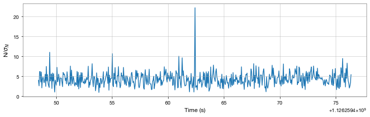

```python
plt.figure(figsize=(12, 4))
plt.subplots_adjust(left=0.1, right=0.9, top=0.85, bottom=0.2)
plt.plot(times, sigs)
plt.xlabel('Time (s)')
plt.ylabel('N/$\sigma_{N}$')
plt.show()
```

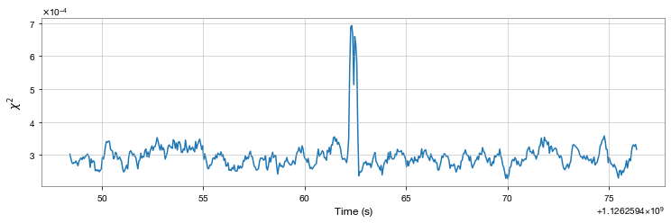

```python
plt.figure(figsize=(12, 4))
plt.subplots_adjust(left=0.1, right=0.9, top=0.85, bottom=0.2)
plt.plot(times, chi2)
plt.xlabel('Time (s)')
plt.ylabel('$\chi^{2}$')
plt.savefig('strain_search_chi2.png')
```

In this figure we can easily find the signal.

# More things to explore

Additionally, you should pull the Livingston and Virgo data and try to see if you can align the different waveforms. Do you see a good coincidence. How do you quantify. Given the alignment what direction are the GWs coming from? Also, you can pull in the official wave forms and try to tune your model. Additionally, it would be nice to know how far the GW occured? How would you compute the distance? What about the other GW events? What parameters do you see? In particular, what does then neutron star merger look like?